# 1B - Exploring Sequence data

Orsolya Bajer-Molnar

2025-07-01

PCA analysis is conducted to see if there are clusters identifiable in the sequence data that is connected to any of the metadata axes.

Added indoor room volume and phase number to the metadata for overlaying

# PCA analysis

I conducted PCA analyses to look at potential trends in the raw data. Since there is an understanding that TPM is affected more by the laboratory pipeline and the primers we use than the original quantities of different viral strains, I ran the PCE with 2 different approaches.

1. Using the **Salmon-TPM** as the readout per sample per target and then calculating the sum of that for each sample and each target
2. Using the count variable to characterize **richness** in each sample for each target, and then summarizing how reach each sample was for each target

I ran the analysis on both the strain and the species level, here i display results for the species level because proportion of variance explained was a little higher for PC1 and PC2 in the species level run for both approaches.

## Salmon-TPM approach

```r
pcavarssp<-c("Sample", "Salmon_TPM", "species")
SeqDataPCAsp<-SeqData[pcavarssp]
str(SeqDataPCAsp)
```

```
## tibble [182 × 3] (S3: tbl_df/tbl/data.frame)
##  $ Sample    : chr [1:182] "GA1_S154810_trimmed_host_filtered_mapped" "GA1_S154810_trimmed_host_filtered_mapped" "GA1_S154810_trimmed_host_filtered_mapped" "GA1_S154810_trimmed_host_filtered_mapped" ...
##  $ Salmon_TPM: num [1:182] 350203 84607 322383 242807 453463 ...
##  $ species   : chr [1:182] "Human mastadenovirus C" "Human mastadenovirus B" "Primate bocaparvovirus 1" "Severe acute respiratory syndrome-related coronavirus" ...
```

```r
####Summarizing Salmon TPM by sample and species
SeqDataPCAsp_agg <- SeqDataPCAsp %>%
  group_by(Sample, species) %>%
  summarise(Salmon_TPM = sum(Salmon_TPM, na.rm = TRUE), .groups = "drop")

tpm_matrixsp <- SeqDataPCAsp_agg %>%
  pivot_wider(names_from = species, values_from = Salmon_TPM, values_fill = 0)

tpm_matrixsp_numeric <- as.matrix(tpm_matrixsp[, -1])
rownames(tpm_matrixsp_numeric) <- tpm_matrixsp$Sample  # Set row names as SampleID

####Running PCA
pca_seqsp <- prcomp(tpm_matrixsp_numeric, center = TRUE, scale. = TRUE)

loadingssp<-pca_seqsp$rotation
print(loadingssp)
```

```
##                                                               PC1          PC2
## Human mastadenovirus B                                -0.54212646 -0.139200511
## Human mastadenovirus C                                -0.18808812 -0.120275114
## Primate bocaparvovirus 1                              -0.09032686 -0.082354380
## Severe acute respiratory syndrome-related coronavirus -0.54356784 -0.136820418
## Human coronavirus 229E                                 0.05790102 -0.062696552
## Human coronavirus HKU1                                 0.02834600 -0.031881882
## Human coronavirus NL63                                 0.03127194 -0.013472066
## Human respirovirus 3                                   0.02078862 -0.030706947
## Respiratory syncytial virus                            0.07050246 -0.071865295
## Rhinovirus B                                           0.03687837 -0.049726128
## Rhinovirus C                                           0.04584984 -0.072073884
## Rhinovirus A                                           0.05764521  0.035681559
## Betacoronavirus 1                                      0.07148998  0.041280905
## Influenza A virus                                     -0.09665571  0.686061726
## Rabbit coronavirus HKU14                               0.05668187  0.056015993
## Human endogenous retrovirus K                         -0.24191020  0.635844959
## Human orthopneumovirus                                 0.04605755  0.039988529
## Human metapneumovirus                                 -0.04472613 -0.141938470
## Human orthorubulavirus 2                               0.01524677 -0.101358797
## Metapneumovirus sp.                                    0.02837128 -0.024950601
## Betapapillomavirus 1                                  -0.51578076 -0.080858112
## Influenza B virus                                      0.02658285  0.003154592
## Human respirovirus 1                                   0.02978695  0.028494491
## Alphapolyomavirus quintihominis                        0.02838250 -0.025595160
##                                                                PC3          PC4
## Human mastadenovirus B                                 0.051063180  0.008629592
## Human mastadenovirus C                                -0.027096761  0.048514171
## Primate bocaparvovirus 1                              -0.018636634  0.043359013
## Severe acute respiratory syndrome-related coronavirus -0.028862526  0.023994269
## Human coronavirus 229E                                -0.450052871 -0.347177420
## Human coronavirus HKU1                                 0.012648816 -0.008000936
## Human coronavirus NL63                                 0.001694665 -0.010098731
## Human respirovirus 3                                  -0.056199366 -0.089287513
## Respiratory syncytial virus                            0.076499536 -0.006334625
## Rhinovirus B                                           0.041051702 -0.118174451
## Rhinovirus C                                           0.117271543 -0.168959877
## Rhinovirus A                                           0.043800262 -0.001094965
## Betacoronavirus 1                                      0.474238858  0.049663949
## Influenza A virus                                      0.016362998 -0.103039438
```

[output cut: 370 more lines]

```
## Rhinovirus B                                          -1.727636e-01
## Rhinovirus C                                          -2.070343e-01
## Rhinovirus A                                          -3.481526e-01
## Betacoronavirus 1                                     -3.136830e-01
## Influenza A virus                                     -1.539568e-01
## Rabbit coronavirus HKU14                              -3.681151e-02
## Human endogenous retrovirus K                         -3.575388e-03
## Human orthopneumovirus                                -2.963946e-01
## Human metapneumovirus                                 -2.634761e-03
## Human orthorubulavirus 2                              -1.141832e-02
## Metapneumovirus sp.                                   -2.323104e-05
## Betapapillomavirus 1                                  -3.943505e-03
## Influenza B virus                                     -1.652648e-01
## Human respirovirus 1                                  -3.690550e-04
## Alphapolyomavirus quintihominis                       -3.887159e-07
```

```r
summary(pca_seqsp)
```

```
## Importance of components:
##                           PC1     PC2     PC3     PC4     PC5     PC6     PC7
## Standard deviation     1.7445 1.39434 1.33997 1.29747 1.28625 1.20916 1.13161
## Proportion of Variance 0.1268 0.08101 0.07481 0.07014 0.06894 0.06092 0.05336
## Cumulative Proportion  0.1268 0.20781 0.28262 0.35276 0.42170 0.48262 0.53597
##                            PC8     PC9    PC10    PC11   PC12    PC13   PC14
## Standard deviation     1.10588 1.06503 1.04323 1.03402 1.0124 1.00951 0.9968
## Proportion of Variance 0.05096 0.04726 0.04535 0.04455 0.0427 0.04246 0.0414
## Cumulative Proportion  0.58693 0.63419 0.67954 0.72409 0.7668 0.80926 0.8507
##                           PC15    PC16    PC17    PC18    PC19    PC20   PC21
## Standard deviation     0.96528 0.86068 0.73883 0.69776 0.67678 0.63592 0.1204
## Proportion of Variance 0.03882 0.03087 0.02274 0.02029 0.01908 0.01685 0.0006
## Cumulative Proportion  0.88948 0.92035 0.94309 0.96338 0.98246 0.99931 0.9999
##                           PC22     PC23      PC24
## Standard deviation     0.04426 0.008958 5.514e-07
## Proportion of Variance 0.00008 0.000000 0.000e+00
## Cumulative Proportion  1.00000 1.000000 1.000e+00
```

Plotting results

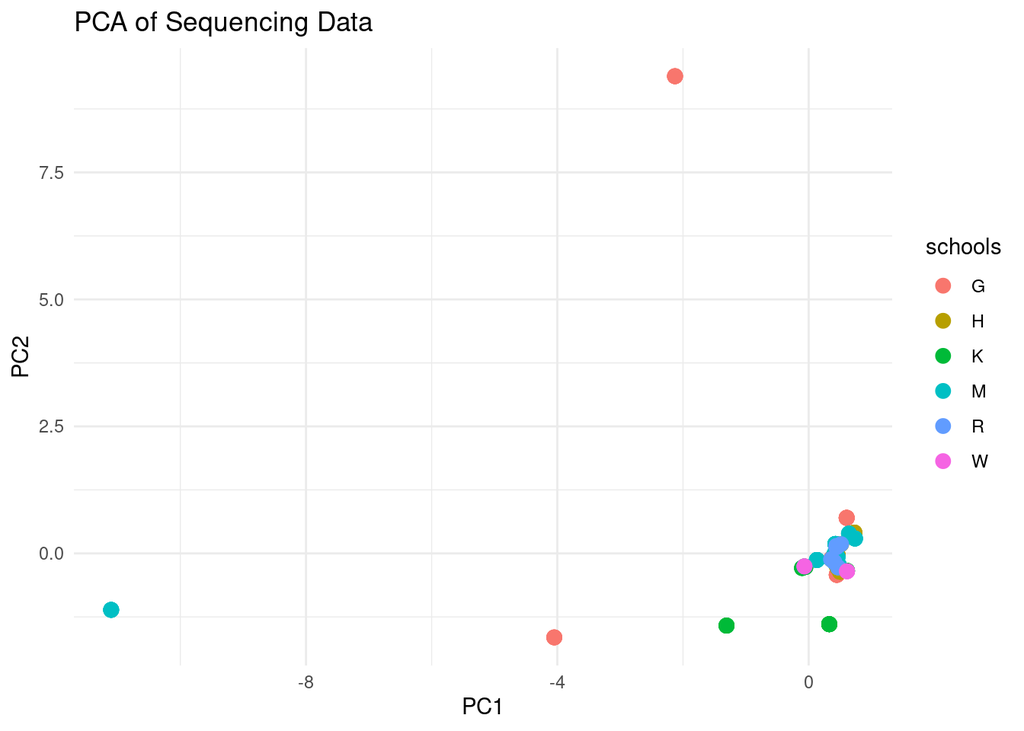

Zooming in to drop 2 most extreme outliers (Plot 1) and the cluster (Plot 2), for the following overlays

SCHOOLS

Plot 1

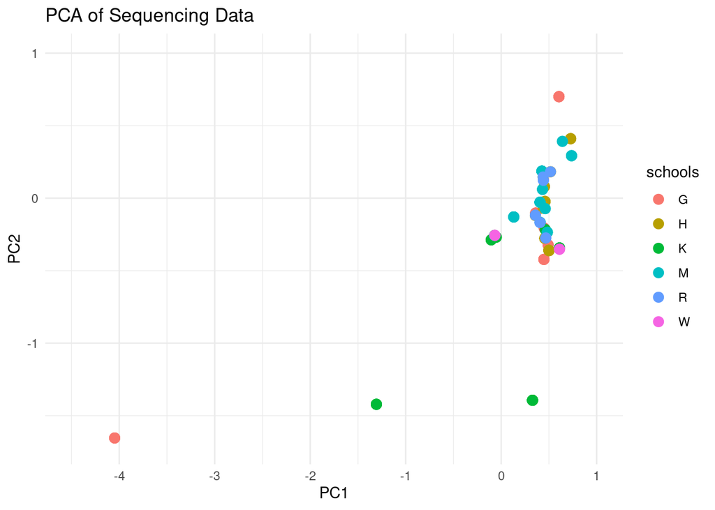

Plot 2

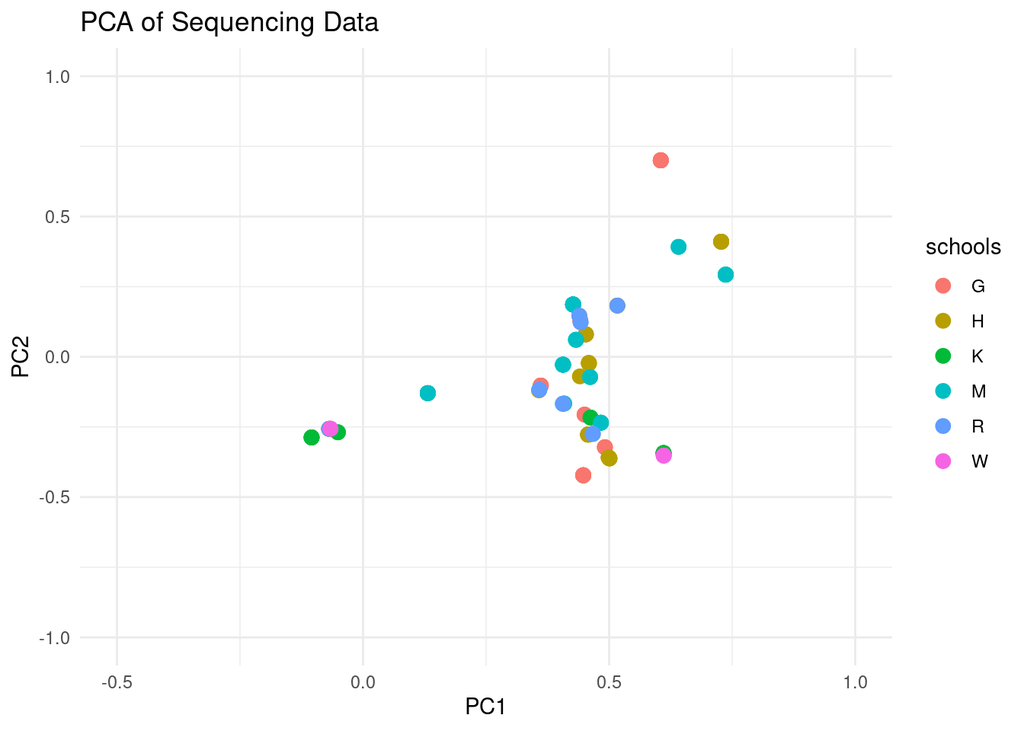

SAMPLE TYPE

Plot 1

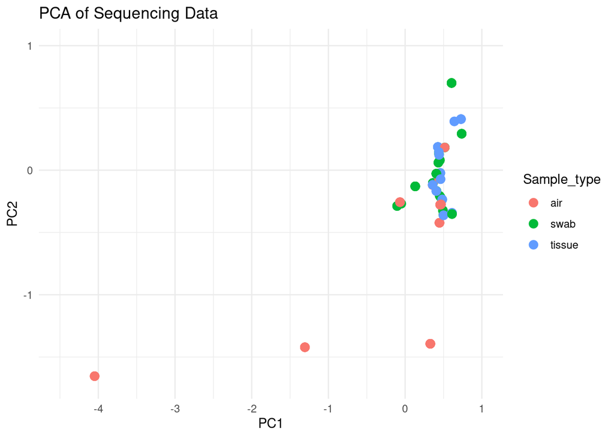

Plot 2

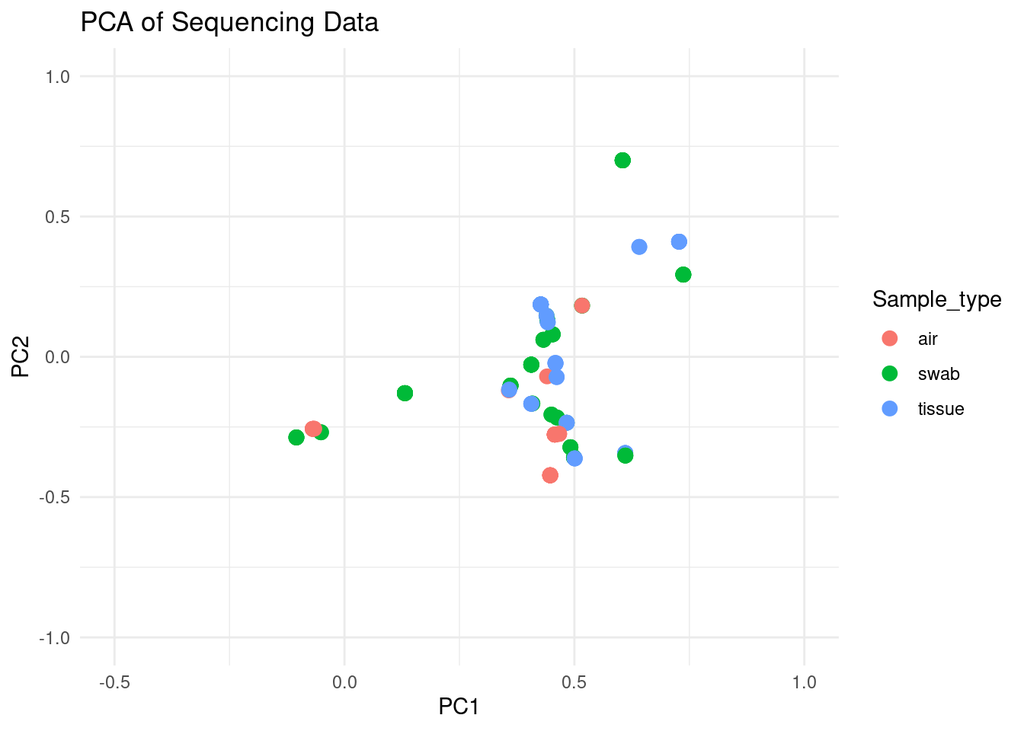

VOLUME

Plot 1

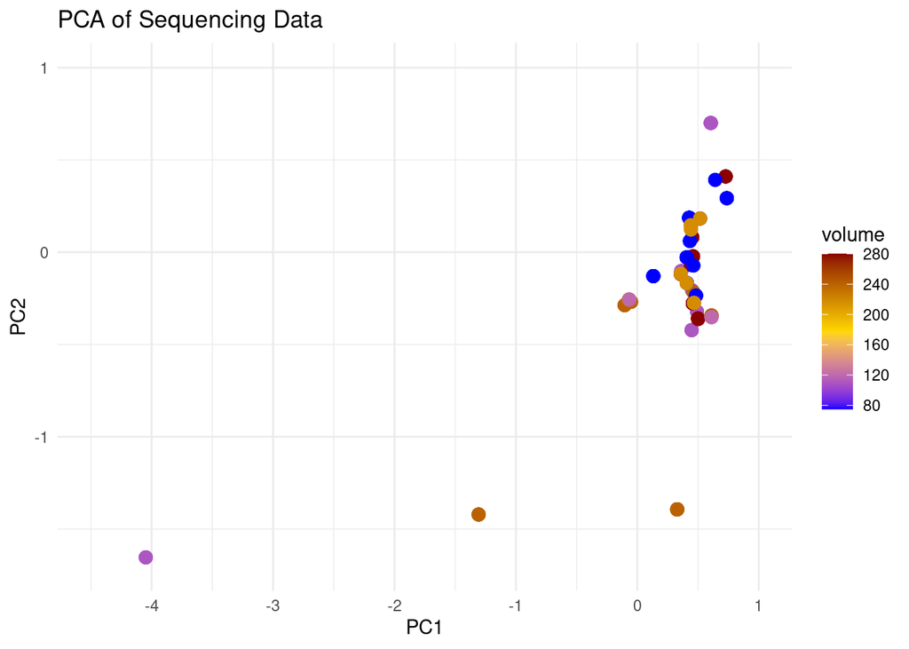

Plot 2

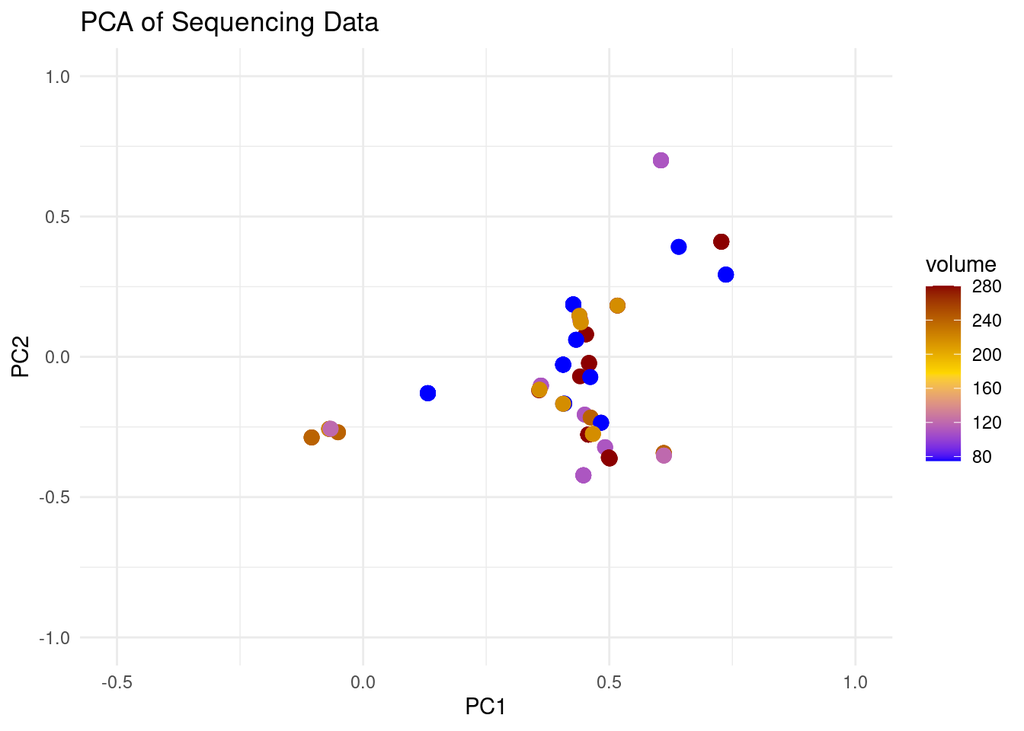

TARGETS (SPECIES)

Plot 1

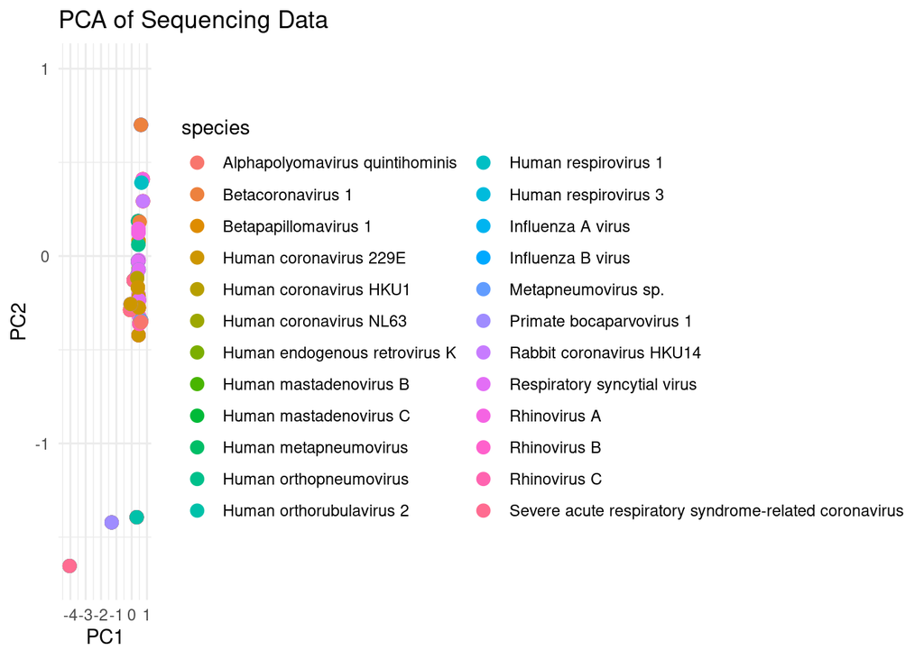

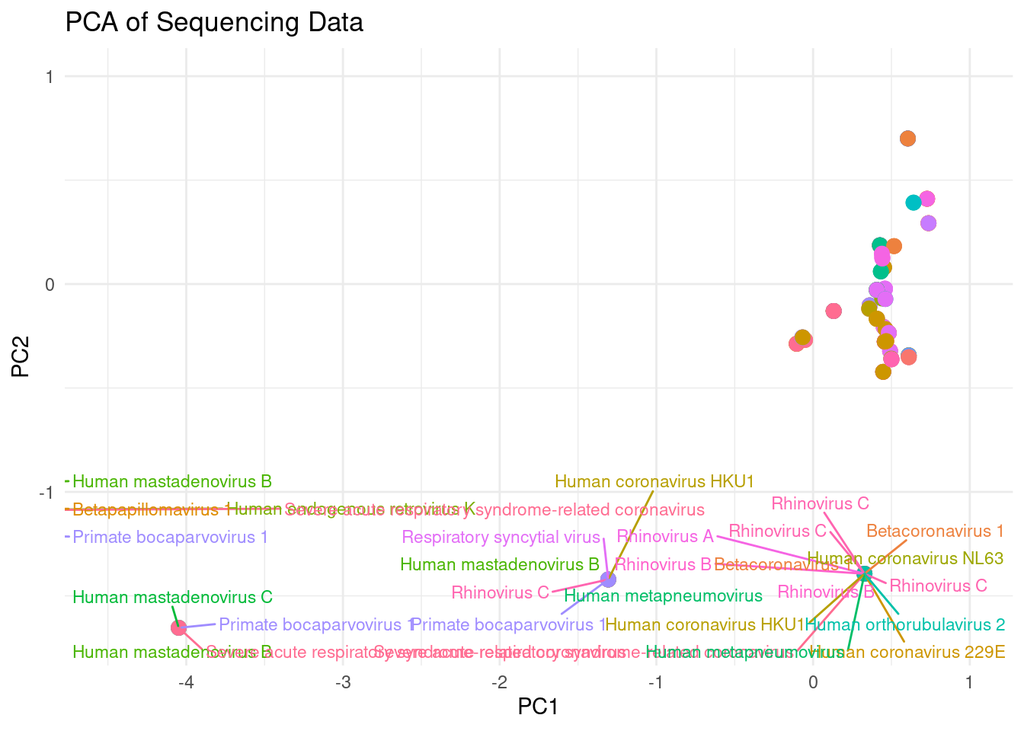

## Richness approach

```r
###Creating the df and adding count of each row
pcavarsspcount<-c("schools", "species", "Sample_type", "Sampling_event", "volume", "phase", "Sample")
PCAspCount<-SeqData[pcavarsspcount]
str(PCAspCount)
```

```
## tibble [182 × 7] (S3: tbl_df/tbl/data.frame)
##  $ schools       : chr [1:182] "G" "G" "G" "G" ...
##  $ species       : chr [1:182] "Human mastadenovirus C" "Human mastadenovirus B" "Primate bocaparvovirus 1" "Severe acute respiratory syndrome-related coronavirus" ...
##  $ Sample_type   : chr [1:182] "air" "air" "air" "air" ...
##  $ Sampling_event: num [1:182] 1 1 1 1 5 5 5 5 5 1 ...
##  $ volume        : num [1:182] 110 110 110 110 110 110 110 110 110 110 ...
##  $ phase         : Factor w/ 2 levels "1","2": 1 1 1 1 1 1 1 1 1 1 ...
##  $ Sample        : chr [1:182] "GA1_S154810_trimmed_host_filtered_mapped" "GA1_S154810_trimmed_host_filtered_mapped" "GA1_S154810_trimmed_host_filtered_mapped" "GA1_S154810_trimmed_host_filtered_mapped" ...
```

```r
PCAspCount$schools<-as.factor(PCAspCount$schools)
PCAspCount$species<-as.factor(PCAspCount$species)
PCAspCount$Sample_type<-as.factor(PCAspCount$Sample_type)
PCAspCount$Sampling_event<-as.factor(PCAspCount$Sampling_event)
PCAspCount$volume<-as.factor(PCAspCount$volume)

PCAspCount$count<-1

####Summarizing count by sample and species
PCAspCount_agg <- PCAspCount %>%
  group_by(Sample, species) %>%
  summarise(count = sum(count, na.rm = TRUE), .groups = "drop")

tpm_matrixcountsp <- PCAspCount_agg %>%
  pivot_wider(names_from = species, values_from = count, values_fill = 0)

tpm_matrixcountsp_numeric <- as.matrix(tpm_matrixcountsp[, -1])
rownames(tpm_matrixcountsp_numeric) <- tpm_matrixcountsp$Sample  # Set row names as SampleID

####Running PCA
pca_seqcountsp <- prcomp(tpm_matrixcountsp_numeric, center = TRUE, scale. = TRUE)

loadingscountsp<-pca_seqcountsp$rotation
print(loadingscountsp)
```

```
##                                                                PC1          PC2
## Human mastadenovirus B                                -0.003610856 -0.442352097
## Human mastadenovirus C                                -0.011177275 -0.280057981
## Primate bocaparvovirus 1                               0.033430266 -0.363665280
## Severe acute respiratory syndrome-related coronavirus  0.251034102 -0.279509532
## Human coronavirus 229E                                 0.202189022  0.083333186
## Human coronavirus HKU1                                 0.328049889  0.012012636
## Human coronavirus NL63                                 0.297314820  0.078278388
## Human respirovirus 3                                   0.164241859 -0.003965801
## Respiratory syncytial virus                            0.051628060  0.131318847
## Rhinovirus B                                           0.413411280  0.042281399
## Rhinovirus C                                           0.419608155  0.015047876
## Rhinovirus A                                           0.177697829  0.160556898
## Betacoronavirus 1                                      0.055253664  0.255381877
## Influenza A virus                                     -0.070593450  0.062965330
## Rabbit coronavirus HKU14                              -0.095707925  0.248855086
## Human endogenous retrovirus K                         -0.060492823 -0.333427247
## Human orthopneumovirus                                -0.110478860  0.084730948
## Human metapneumovirus                                  0.321927422 -0.086351235
## Human orthorubulavirus 2                               0.372579306  0.019482656
## Metapneumovirus sp.                                    0.040289645  0.052053542
## Betapapillomavirus 1                                  -0.025907381 -0.421657199
## Influenza B virus                                     -0.090292910  0.134504267
## Human respirovirus 1                                  -0.063294801  0.016935547
## Alphapolyomavirus quintihominis                       -0.025853020  0.032553479
##                                                                PC3          PC4
## Human mastadenovirus B                                 0.206205661 -0.201188448
## Human mastadenovirus C                                 0.043258068 -0.282450456
## Primate bocaparvovirus 1                              -0.001873952 -0.098061304
## Severe acute respiratory syndrome-related coronavirus  0.116083134 -0.024304548
## Human coronavirus 229E                                -0.244027994  0.153503393
## Human coronavirus HKU1                                -0.065569742  0.057910809
## Human coronavirus NL63                                 0.028358656  0.027028966
## Human respirovirus 3                                  -0.067906194  0.002085923
## Respiratory syncytial virus                           -0.050339805 -0.045801187
## Rhinovirus B                                           0.068028685 -0.005347300
## Rhinovirus C                                           0.054947966 -0.027545870
## Rhinovirus A                                           0.101070763  0.384694645
## Betacoronavirus 1                                      0.461370672 -0.073416122
## Influenza A virus                                      0.284612761  0.450164040
```

[output cut: 270 more lines]

```
## Rhinovirus B                                           0.032057498
## Rhinovirus C                                           0.011443707
## Rhinovirus A                                          -0.008611469
## Betacoronavirus 1                                      0.256568107
## Influenza A virus                                      0.128583585
## Rabbit coronavirus HKU14                              -0.327105514
## Human endogenous retrovirus K                         -0.192332179
## Human orthopneumovirus                                 0.036584876
## Human metapneumovirus                                  0.397982104
## Human orthorubulavirus 2                              -0.328571757
## Metapneumovirus sp.                                    0.024628831
## Betapapillomavirus 1                                   0.432124085
## Influenza B virus                                      0.091922760
## Human respirovirus 1                                  -0.018253090
## Alphapolyomavirus quintihominis                       -0.001426561
```

```r
summary(pca_seqcountsp)
```

```
## Importance of components:
##                           PC1    PC2   PC3     PC4     PC5     PC6     PC7
## Standard deviation     2.0025 1.6535 1.572 1.29917 1.22510 1.19930 1.18366
## Proportion of Variance 0.1671 0.1139 0.103 0.07033 0.06254 0.05993 0.05838
## Cumulative Proportion  0.1671 0.2810 0.384 0.45436 0.51689 0.57682 0.63520
##                           PC8     PC9    PC10    PC11    PC12    PC13    PC14
## Standard deviation     1.1009 1.04889 1.01916 0.93259 0.89159 0.84098 0.77252
## Proportion of Variance 0.0505 0.04584 0.04328 0.03624 0.03312 0.02947 0.02487
## Cumulative Proportion  0.6857 0.73154 0.77482 0.81106 0.84418 0.87365 0.89851
##                          PC15    PC16    PC17    PC18    PC19    PC20    PC21
## Standard deviation     0.7316 0.67454 0.58411 0.53848 0.49504 0.43057 0.37351
## Proportion of Variance 0.0223 0.01896 0.01422 0.01208 0.01021 0.00772 0.00581
## Cumulative Proportion  0.9208 0.93978 0.95399 0.96607 0.97629 0.98401 0.98982
##                           PC22   PC23    PC24
## Standard deviation     0.34429 0.2855 0.21018
## Proportion of Variance 0.00494 0.0034 0.00184
## Cumulative Proportion  0.99476 0.9982 1.00000
```

**Variance explained is actually a bit better than if conducted with TPM** Data cloud isn’t as crazy and all over th eplace as it was with the TPM

Plotting results with the following overlays

SCHOOLS

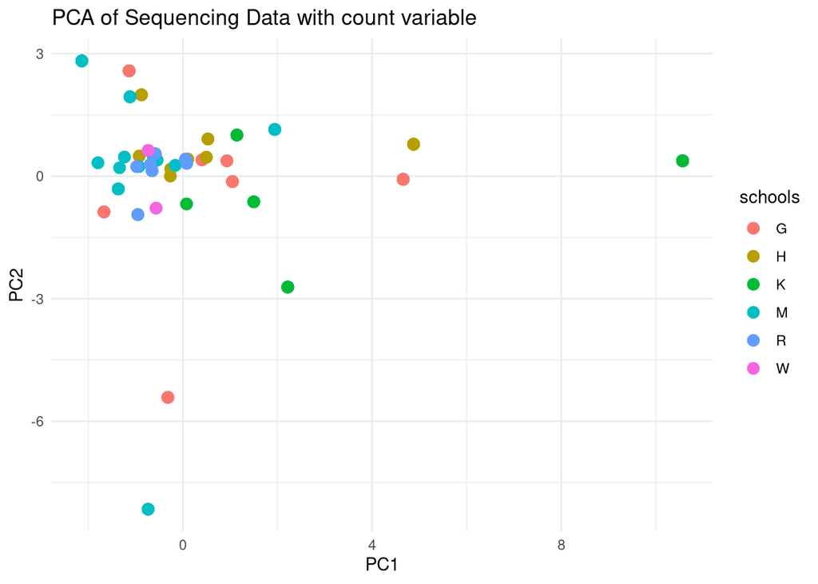

SAMPLE TYPE

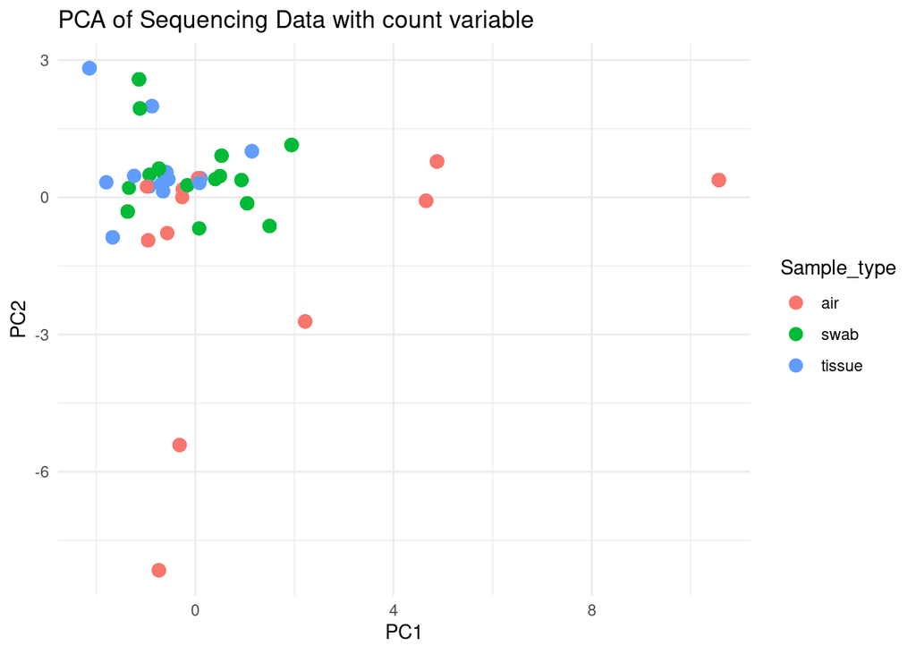

VOLUME

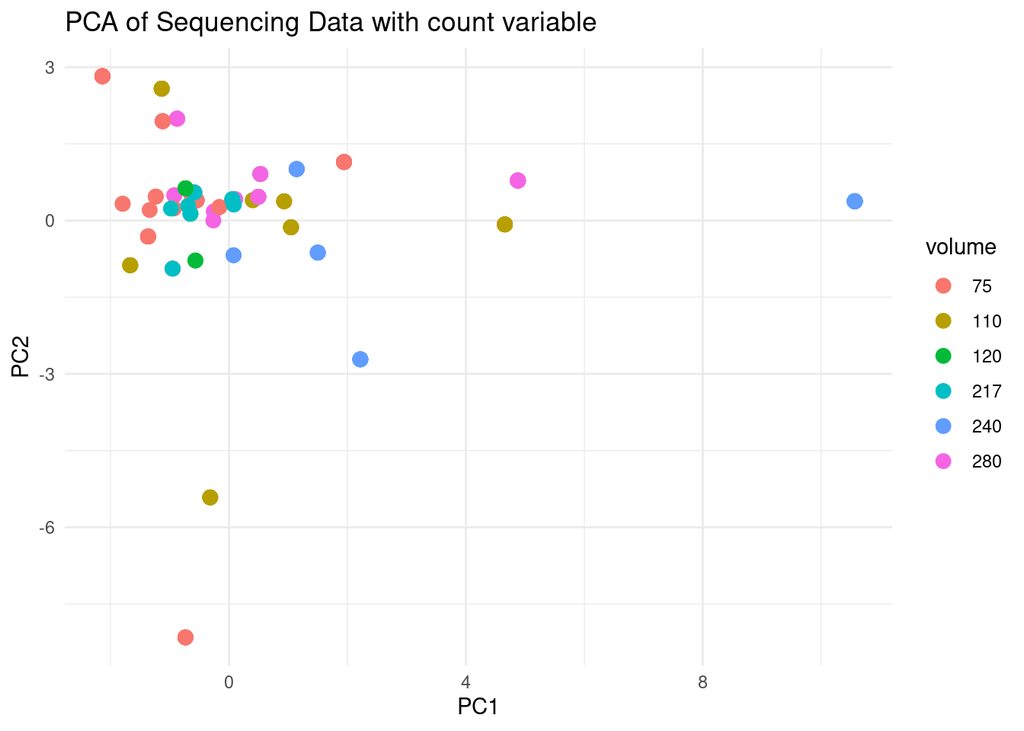

TARGETS (SPECIES)

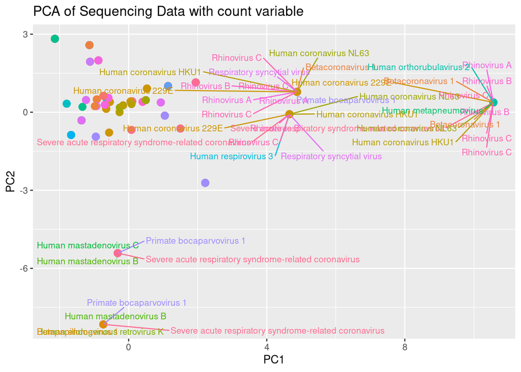